# How Loan Characteristics affect Borrower's APR

## Investigation Overview

This slide deck is very much focused on Borrower's APR and its various influencers. The other main attributes considered for the investigation are Loan amount, Monthly Income, Loan Term, Employment Status, Prosper Score and Prosper Rating. We analyze this data and understand what factor affects Borrower's APR the most and its relationship with all the other attributes.

## Dataset Overview

The original dataset consists of 113,917 loan data records. Several attributes were dropped as they were not considered in further analysis. Since Borrower's APR is the key attribute of interest, all records with no APR data was dropped as well to give better results.

## Distribution of Borrower APR

With more than one peak, the APR distribution is a multimodal distribution. It has a small peak centered around 0.08, a large peak at around 0.18, followed by another small peak at 0.29, an exceptionally high peak at 0.35, and another small peak at 0.37 of APR rates.

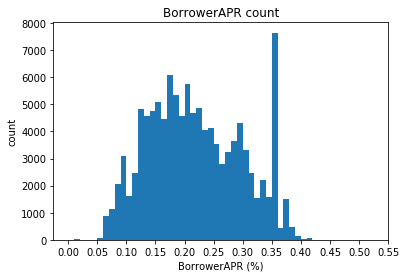

```python
bins = np.arange(0, df_sub['BorrowerAPR'].max(), 0.01)
plt.hist(data = df_sub, x = 'BorrowerAPR', bins = bins)
plt.title('BorrowerAPR count')
plt.xlabel('BorrowerAPR (%)')
plt.ylabel('count')
plt.xticks(np.arange(0, df_sub['BorrowerAPR'].max()+0.05, 0.05));
```

## Borrower APR vs Prosper Score

Prosper score has the strongest negative correlation to Borrower APR. It decreases with incrase in Prosper Score. Borrowers with higher Prosper Scores have lower APR rates.

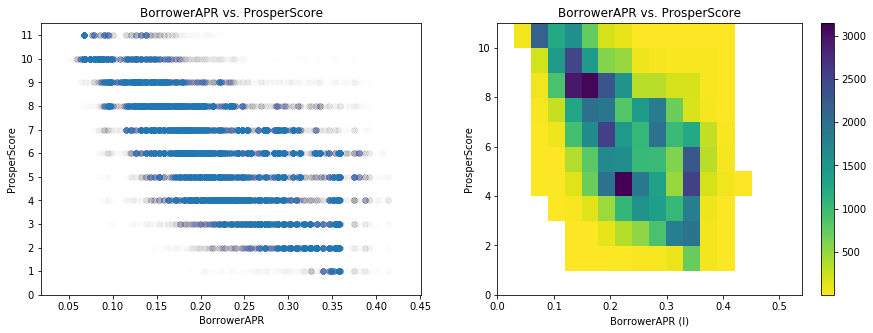

```python
# Heat plot and scatter plot for Borrower APR & Prosper Score

plt.figure(figsize = [15, 5])

plt.subplot(1, 2, 1)
plt.scatter(data = df_sub, x = 'BorrowerAPR', y = 'ProsperScore', alpha =  0.005)
plt.yticks(np.arange(0, 12, 1))
plt.title('BorrowerAPR vs. ProsperScore')
plt.xlabel('BorrowerAPR')
plt.ylabel('ProsperScore')


plt.subplot(1, 2, 2)
bins_x = np.arange(0, df_sub['BorrowerAPR'].max()+0.05, 0.03)
bins_y = np.arange(0, df_sub['ProsperScore'].max()+1, 1)
plt.hist2d(data = df_sub, x = 'BorrowerAPR', y = 'ProsperScore', bins = [bins_x, bins_y],
               cmap = 'viridis_r', cmin = 0.5)
plt.colorbar()
plt.title('BorrowerAPR vs. ProsperScore')
plt.xlabel('BorrowerAPR (l)')
plt.ylabel('ProsperScore');
```

## Borrower APR vs Loan Amount

The range across which APR rate varies decreases as the Loan amount increases. Overall, APR rate is negatively correlated with Loan Amount which means higher the Loan, lower the APR.

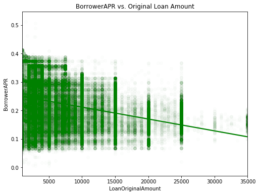

```python
plt.figure(figsize = [8, 6])
plt.title('BorrowerAPR vs. Original Loan Amount')
sb.regplot(data = df_sub, x = 'LoanOriginalAmount', y = 'BorrowerAPR', scatter_kws={'alpha':0.01},color = 'green');
```

## Borrower APR vs Monthly Income

Majority of borrowers earn monthly income less than 15,000 dollars. Although the correlation does not seem very strong from the visual below, overall APR is negatively correlated with monthly income.

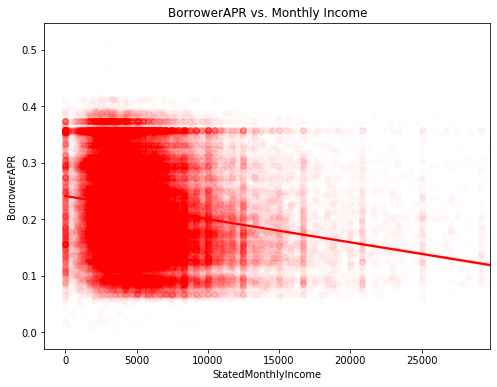

```python
plt.figure(figsize = [8, 6])
plt.title('BorrowerAPR vs. Monthly Income')
sb.regplot(data = df_sub, x = 'StatedMonthlyIncome', y = 'BorrowerAPR', scatter_kws={'alpha':0.01},color = 'red');
xticks = [5000,10000,15000,20000,25000]
```

## Borrower APR vs Employment

Employed, Self-employed and Full-time have a higher monthly income and loan amounts, not considering 'Not available' and 'Other' records. Borrower APR is clearly highest for those who are not employed.

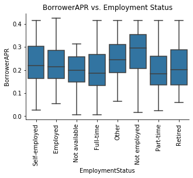

```python
cat_vars = ['EmploymentStatus']

def boxgrid(x, y, **kwargs):
    """ Quick hack for creating box plots with seaborn's PairGrid. """
    default_color = sb.color_palette()[0]
    sb.boxplot(x, y, color = default_color)



g = sb.PairGrid(data = df_sub, y_vars = ['BorrowerAPR'],
                x_vars = cat_vars, size = 3, aspect = 1.5)

g.map(boxgrid);
plt.title('BorrowerAPR vs. Employment Status')
plt.xticks(rotation=90);
```

## Borrower APR vs Prosper Rating & Prosper Score

We can see the borrower APR rates for all individual Prosper Ratings below and we see that APR is highest and even crosses 0.4 for HR rated borrowers, followed by E rated borrowers. It is generally lowest for AA rated borrowers, upto a max of 0.2.

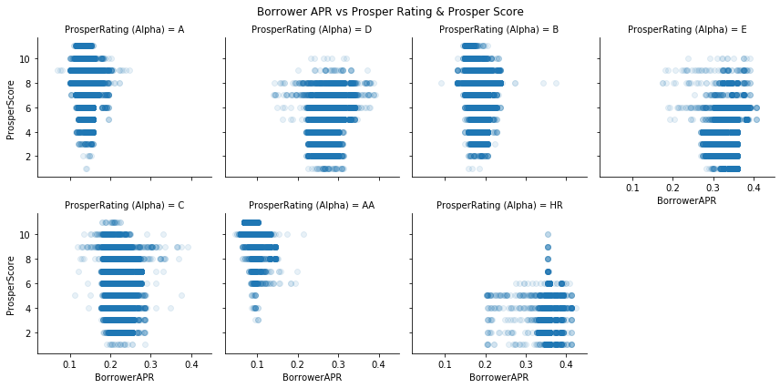

```python
g = sb.FacetGrid(data = df_sub, col = 'ProsperRating (Alpha)', col_wrap = 4, size = 3)

g.map(plt.scatter, 'BorrowerAPR', 'ProsperScore', alpha = 0.1)

g.set_xlabels('BorrowerAPR')
g.set_ylabels('ProsperScore')
plt.subplots_adjust(top=0.9)
g.fig.suptitle('Borrower APR vs Prosper Rating & Prosper Score')
plt.show()
```

## Borrower APR by Rating and Term

When we add Loan Term into this analysis, an interesting observation can be made. For lower Prosper Ratings, APR rates decrease with longer terms and as the Prosper Ratings get better, APR rates increase with longer terms. Overall, APR decreases with better Prosper Rating

```
[]
```

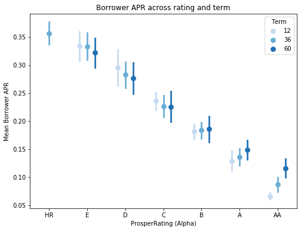

```python
fig = plt.figure(figsize = [8,6])
ax = sb.pointplot(data = df_sub, x = 'ProsperRating (Alpha)', y = 'BorrowerAPR', hue = 'Term',
           palette = 'Blues', linestyles = '', dodge = 0.4, ci='sd',order = ['HR','E','D','C','B','A','AA'])

plt.title('Borrower APR across rating and term')
plt.ylabel('Mean Borrower APR')
ax.set_yticklabels([],minor = True)
```